# Overview

This codebook summarizes the findings and data from the University of Washington (UW) 2023 Seattle area homeless count project. The count was led by Zack W. Almquist (*Lead - PI*), Paul Hebert (*Co-PI*), Nathalie Williams (*Puget Sound Data Oversample PI*), Amy Hagopian (*Co-PI*), June (Junhe) Yang (*Data Scientist Lead DSSG PhD*).

The data were collected using two different surveys, referred to as **UWRDS** and **UWRDS-PSD** in the codebook. Data from both surveys were harmonized for this codebook. We note where question phrasing differed across surveys and when a variable was collected in only one survey.

This codebook and corresponding links were compiled by Data Science for Social Good (DSSG) summer fellows, in alphabetical order:  
- Felix Junior Appiah Kubi,  
- Brooke Kaye,  
- Jess Robinson, and  
- Rebecca Schachtman,  
with the support of Data Scientist, June (Junhe) Yang, and Project Lead, Zack Almquist.

We employ RDS methods for the population level statistics (details, [here](https://uwescience.github.io/DSSG2024_understanding_homelessness/method1/)). For information on funding and a full list of contributors, see [Acknowledgements](https://uwescience.github.io/DSSG2024_understanding_homelessness/acknowledgements/).

# Demographics

## *Gender*

*Imputed based on ‘B4. How would you describe your gender?’ [UWRDS-PSD] and ‘25. Which of the following best describes your gender?’ [UWRDS]*

Gender

Sample N

Sample Proportion

RDS II Estimate

RDS II 95% CI

A gender other than singularly female or male (e.g., nonbinary, genderfluid, agender, culturally specific gender)

10

0.99%

1.27%

[0.45%, 2.09%]

Do not know

1

0.10%

0.13%

[-0.07%, 0.33%]

Female

277

27.34%

26.54%

[20.74%, 32.34%]

Male

717

70.78%

71.31%

[65.51%, 77.10%]

Questioning

5

0.49%

0.41%

[0.28%, 0.53%]

Transgender

3

0.30%

0.35%

[-0.09%, 0.79%]

Total

1013

100.00%

100.00%

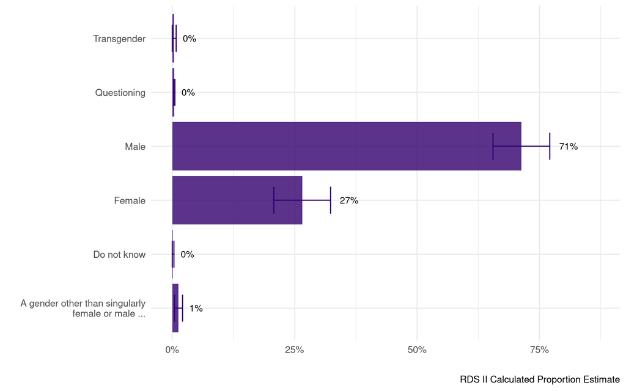

## *Race*

*Imputed based on ‘B18. Which one or more of the following would you say best describes your race, heritage, or ancestry?’ [UWRDS-PSD] and ‘23. Which racial groups do you identify with?’ [UWRDS]*

### *Race (Overall)*

Race

Sample N

Sample Proportion

RDS II Estimate

RDS II 95% CI

American Indian, Alaskan Native or Indigenous

77

7.96%

8.91%

[5.17%, 12.65%]

Another race

14

1.45%

2.18%

[0.14%, 4.22%]

Asian or Asian American

20

2.07%

2.74%

[-0.03%, 5.51%]

Black, African American, or African

163

16.86%

18.63%

[13.53%, 23.73%]

Do not know

17

1.76%

2.15%

[-0.45%, 4.75%]

Multiracial

129

13.34%

13.42%

[9.30%, 17.54%]

Native Hawaiian or Pacific Islander

24

2.48%

2.28%

[0.75%, 3.82%]

White

523

54.08%

49.69%

[43.47%, 55.90%]

Total

967

100.00%

100.00%

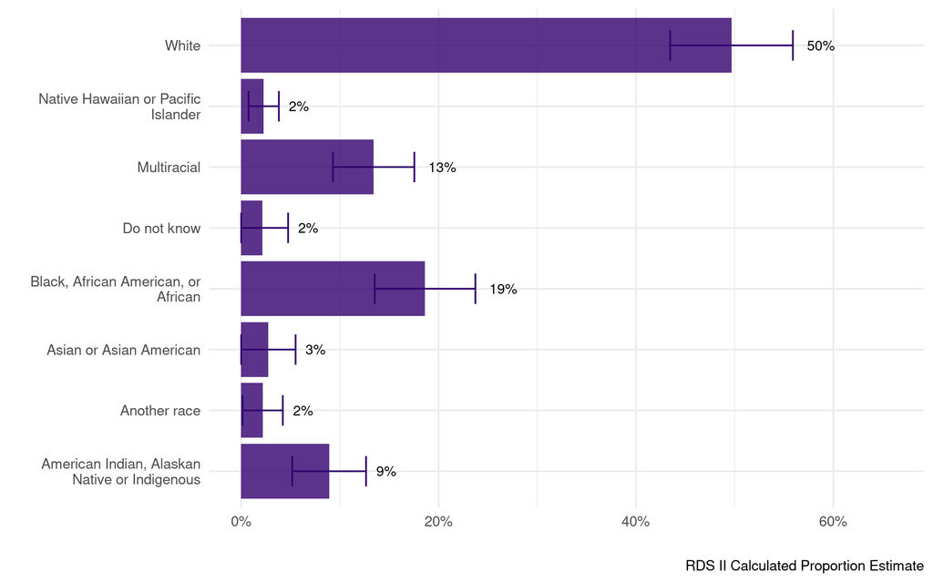

### *Race - Multiracial Preference*

*Imputed based on ‘ego_race_all’ classifying multiracial individuals as a single race, with preference to Black*

Race

Sample N

Sample Proportion

RDS II Estimate

RDS II 95% CI

American Indian, Alaskan Native or Indigenous

136

14.06%

15.25%

[10.64%, 19.86%]

Another race

14

1.45%

2.18%

[0.14%, 4.22%]

Asian or Asian American

25

2.59%

3.26%

[0.44%, 6.08%]

Black, African American, or African

217

22.44%

23.63%

[18.34%, 28.92%]

Do not know

17

1.76%

2.15%

[-0.45%, 4.75%]

Native Hawaiian or Pacific Islander

32

3.31%

3.56%

[0.89%, 6.22%]

White

526

54.40%

49.97%

[43.75%, 56.20%]

Total

967

100.00%

100.00%

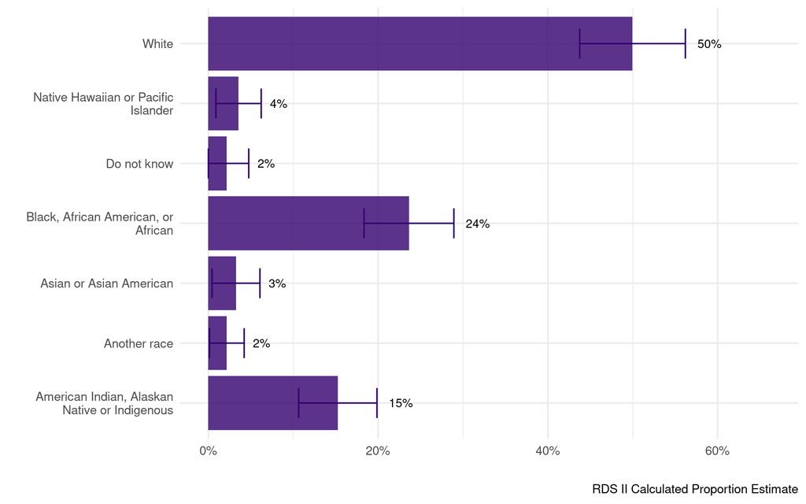

### *Race - Multiracial (Indigenous)*

*Imputed based on ‘ego_race_all’ classifying multiracial individuals as a single race, with preference to Indigenous*

Race

Sample N

Sample Proportion

RDS II Estimate

RDS II 95% CI

American Indian, Alaskan Native or Indigenous

177

18.30%

19.01%

[14.19%, 23.83%]

Another race

14

1.45%

2.18%

[0.14%, 4.22%]

Asian or Asian American

25

2.59%

3.26%

[0.44%, 6.08%]

Black, African American, or African

176

18.20%

19.87%

[14.74%, 25.01%]

Do not know

17

1.76%

2.15%

[-0.45%, 4.75%]

Native Hawaiian or Pacific Islander

32

3.31%

3.56%

[0.89%, 6.22%]

White

526

54.40%

49.97%

[43.75%, 56.20%]

Total

967

100.00%

100.00%

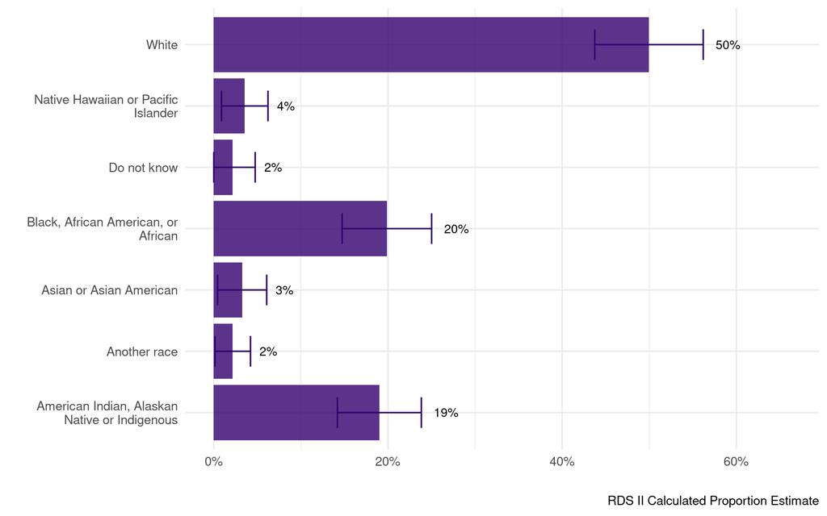

### *Race - Multiracial (Native Hawaiian or Pacific Islander)*

*Imputed based on ‘ego_race_all’ classifying multiracial individuals as a single race, with preference to Native Hawaiian or Pacific Islander*

Race

Sample N

Sample Proportion

RDS II Estimate

RDS II 95% CI

American Indian, Alaskan Native or Indigenous

129

13.34%

14.22%

[9.71%, 18.72%]

Another race

14

1.45%

2.18%

[0.14%, 4.22%]

Asian or Asian American

25

2.59%

3.26%

[0.44%, 6.08%]

Black, African American, or African

197

20.37%

21.58%

[16.32%, 26.84%]

Do not know

17

1.76%

2.15%

[-0.45%, 4.75%]

Native Hawaiian or Pacific Islander

59

6.10%

6.65%

[3.64%, 9.65%]

White

526

54.40%

49.97%

[43.75%, 56.20%]

Total

967

100.00%

100.00%

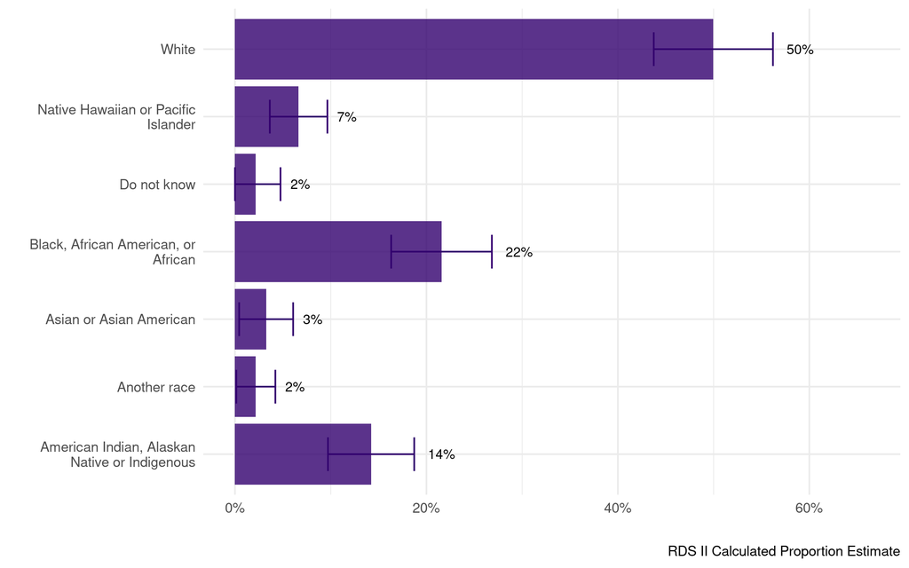

## *Ethnicity*

*Imputed based on ‘B16. Do you consider yourself Hispanic or Latinx’ [UWRDS-PSD] and ‘24. What is your ethnicity?’ [UWRDS]*

Ethnicity

Sample N

Sample Proportion

RDS II Estimate

RDS II 95% CI

Do not know

21

2%

2%

[0%, 4%]

Hispanic/Latin(a)(o)(x)

146

15%

15%

[11%, 20%]

Non-Hispanic/Non-Latin(a)(o)(x)

820

83%

83%

[78%, 87%]

Total

987

100%

100%

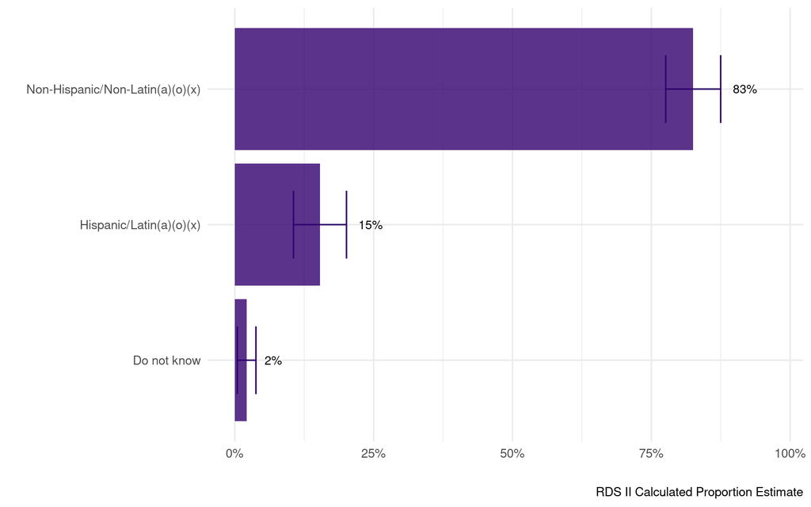

## *Age*

*Date of Birth*

### *Age (Categorical)*

*Imputed based on ‘A2. How old are you?’ [UWRDS-PSD] and ‘4. Date of Birth’ [UWRDS]*

Age - Categorical

Sample N

Sample Proportion

RDS II Estimate

RDS II 95% CI

18-24

26

2.5%

3.4%

[0.5%, 6.2%]

25-34

208

20.4%

21.2%

[16.0%, 26.3%]

35-44

302

29.7%

28.6%

[23.3%, 34.0%]

45-54

240

23.6%

22.8%

[17.8%, 27.9%]

55-64

180

17.7%

16.9%

[13.3%, 20.6%]

65+

62

6.1%

7.1%

[3.7%, 10.5%]

Total

1018

100.0%

100.0%

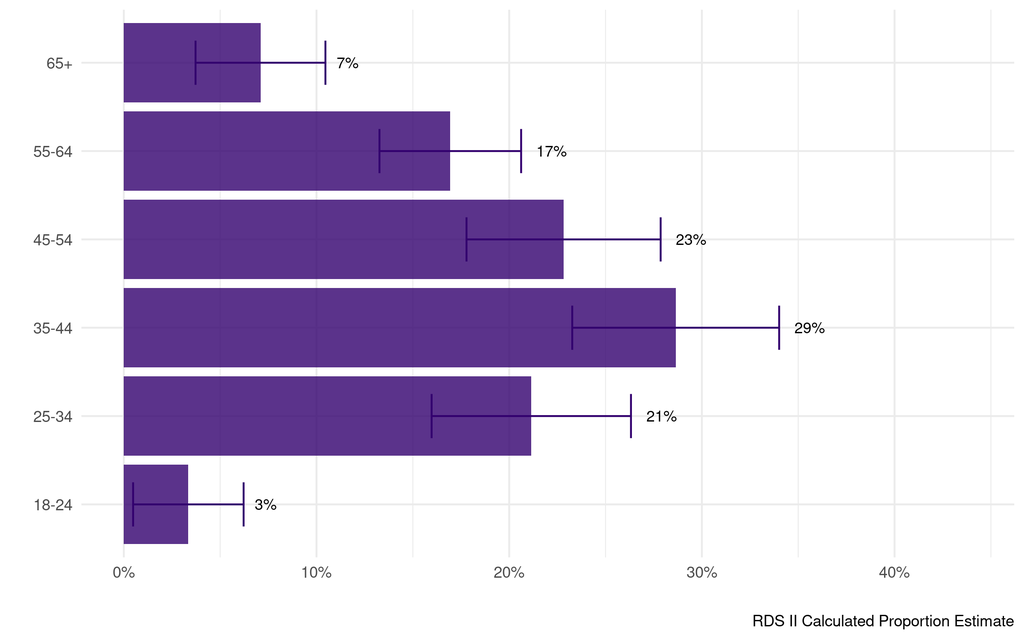

### *Age (Continuous)*

*Age - Imputed from ‘4. Date of Birth’*

| Age - Continuous | Sample N | Sample Median | Sample Mean | Sample SE | RDS II Estimate | RDS II 95% CI |
| --- | --- | --- | --- | --- | --- | --- |
| • | 1018 | 43 | 44.73 | 0.39 | 44.63 | [42.93, 46.32] |

## *Birthplace*

### *Birth State*

*8. Birthplace: - State - In what city and state were you born? - Imputed. This variable is not included for UWRDS-PSD survey observations.*

Birth State

Sample N

Sample Proportion

RDS II Estimate

RDS II 95% CI

Alabama

6

0.77%

1.140%

[-1.27%, 3.540%]

Alaska

17

2.19%

1.870%

[1.04%, 2.700%]

Arizona

8

1.03%

1.550%

[-0.93%, 4.030%]

Arkansas

5

0.64%

0.810%

[0.06%, 1.550%]

California

85

10.94%

9.760%

[6.17%, 13.350%]

Colorado

12

1.54%

1.140%

[0.72%, 1.560%]

Connecticut

2

0.26%

0.090%

[0.06%, 0.110%]

Florida

25

3.22%

4.740%

[0.99%, 8.490%]

Georgia

5

0.64%

0.930%

[-0.45%, 2.310%]

Hawaii

5

0.64%

0.840%

[-1.27%, 2.950%]

Idaho

6

0.77%

1.000%

[-0.65%, 2.650%]

Illinois

16

2.06%

2.190%

[1.01%, 3.380%]

Indiana

4

0.51%

0.610%

[0.39%, 0.840%]

Iowa

5

0.64%

1.060%

[-1.73%, 3.850%]

Kansas

10

1.29%

1.590%

[-0.78%, 3.970%]

Kentucky

6

0.77%

0.540%

[-0.14%, 1.230%]

Louisiana

8

1.03%

1.090%

[-0.68%, 2.850%]

Maine

1

0.13%

0.090%

[0.07%, 0.110%]

Massachusetts

4

0.51%

0.590%

[0.31%, 0.870%]

Michigan

13

1.67%

1.450%

[0.76%, 2.140%]

Minnesota

10

1.29%

2.180%

[0.01%, 4.350%]

Mississippi

2

0.26%

0.170%

[-0.01%, 0.350%]

Missouri

8

1.03%

0.720%

[0.07%, 1.370%]

Montana

17

2.19%

1.800%

[-0.36%, 3.960%]

Nebraska

4

0.51%

0.550%

[-1.36%, 2.460%]

Nevada

1

0.13%

0.370%

[0.17%, 0.560%]

New Hampshire

1

0.13%

0.180%

[-0.47%, 0.840%]

New Jersey

8

1.03%

1.180%

[-0.36%, 2.720%]

New Mexico

7

0.90%

1.060%

[-1.19%, 3.310%]

New York

11

1.42%

1.480%

[-0.32%, 3.280%]

North Carolina

4

0.51%

0.580%

[-0.07%, 1.230%]

North Dakota

5

0.64%

0.520%

[0.32%, 0.720%]

Ohio

10

1.29%

1.910%

[-0.30%, 4.130%]

Oklahoma

7

0.90%

1.160%

[-0.74%, 3.060%]

Oregon

20

2.57%

2.700%

[1.38%, 4.030%]

Pennsylvania

8

1.03%

1.040%

[-1.03%, 3.110%]

South Carolina

4

0.51%

0.250%

[0.11%, 0.400%]

South Dakota

2

0.26%

0.210%

[-0.50%, 0.920%]

Tennessee

9

1.16%

0.670%

[-0.03%, 1.370%]

Texas

21

2.70%

3.100%

[1.56%, 4.640%]

Utah

4

0.51%

0.510%

[-0.17%, 1.190%]

Vermont

1

0.13%

0.090%

[0.01%, 0.180%]

Virginia

3

0.39%

0.560%

[-1.32%, 2.450%]

Washington

357

45.95%

42.540%

[35.83%, 49.250%]

West Virginia

4

0.51%

0.470%

[-0.17%, 1.120%]

Wisconsin

5

0.64%

0.790%

[0.15%, 1.430%]

Wyoming

1

0.13%

0.120%

[0.09%, 0.150%]

Total

777

100.00%

100.000%

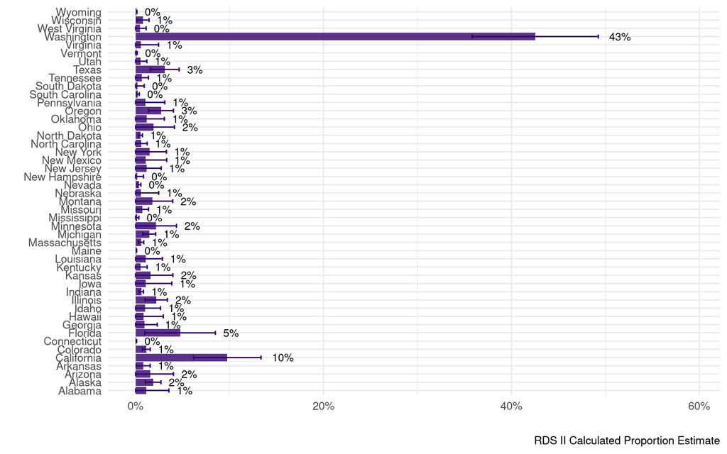

### *Birth Country*

*8. Birthplace: - Country - In what city and state were you born? - Imputed. This variable is not included for UWRDS-PSD survey observations.*

Birth Country

Sample N

Sample Proportion

RDS II Estimate

RDS II 95% CI

Burma

1

0.12%

0.34%

[-1.030%, 1.700%]

Canada

4

0.48%

0.81%

[-1.110%, 2.740%]

Costa Rica

1

0.12%

0.34%

[0.270%, 0.410%]

Dominican Republic

1

0.12%

0.03%

[0.020%, 0.050%]

Ethiopia

3

0.36%

0.59%

[0.360%, 0.820%]

France

1

0.12%

0.17%

[-0.170%, 0.500%]

Germany

3

0.36%

0.42%

[-1.110%, 1.940%]

Grenada

1

0.12%

0.17%

[-0.300%, 0.630%]

Guam

2

0.24%

0.45%

[-0.860%, 1.760%]

Haiti

1

0.12%

0.08%

[0.060%, 0.110%]

Honduras

1

0.12%

0.11%

[-0.030%, 0.250%]

India

2

0.24%

0.17%

[0.120%, 0.220%]

Iran

1

0.12%

0.17%

[0.130%, 0.210%]

Italy

1

0.12%

0.17%

[-0.130%, 0.470%]

Japan

1

0.12%

0.06%

[0.040%, 0.080%]

Jordan

1

0.12%

0.17%

[-0.500%, 0.830%]

Kazakhstan

2

0.24%

0.19%

[-0.050%, 0.430%]

Kenya

2

0.24%

0.08%

[0.020%, 0.140%]

Korea

1

0.12%

0.04%

[0.010%, 0.060%]

Laos

1

0.12%

0.17%

[0.070%, 0.270%]

Lebanon

1

0.12%

0.11%

[0.020%, 0.210%]

Lunpranba

1

0.12%

0.17%

[0.020%, 0.320%]

Marianas islands

1

0.12%

0.02%

[0.010%, 0.030%]

Mexico

5

0.60%

0.85%

[0.140%, 1.570%]

Mumbai india

1

0.12%

0.34%

[-1.290%, 1.960%]

Palau

1

0.12%

0.08%

[-0.030%, 0.200%]

Philippines

4

0.48%

0.66%

[-0.940%, 2.250%]

Puerto Rico

1

0.12%

0.11%

[-0.180%, 0.410%]

Romania

1

0.12%

0.11%

[0.050%, 0.180%]

Russia

1

0.12%

0.17%

[-0.450%, 0.780%]

Scotland

1

0.12%

0.17%

[-0.350%, 0.680%]

Somalia

2

0.24%

0.13%

[0.030%, 0.240%]

South korea

1

0.12%

0.11%

[0.080%, 0.150%]

UK

1

0.12%

0.11%

[-0.140%, 0.360%]

Ukraine

1

0.12%

0.11%

[-0.060%, 0.280%]

United States

779

93.52%

92.02%

[88.060%, 95.980%]

Total

833

100.00%

100.00%

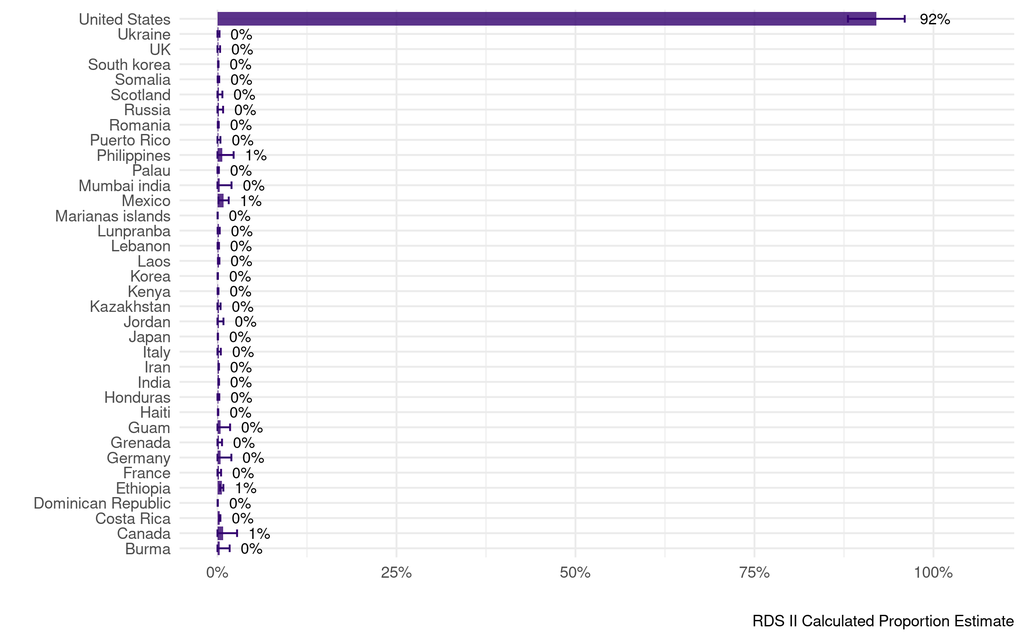

## *Years Lived in King County*

*9. How long have you lived in King County? - Imputed. This variable is not included for UWRDS-PSD survey observations.*

| King County Tenure | Sample N | Sample Median | Sample Mean | Sample SE | RDS II Estimate | RDS II 95% CI |
| --- | --- | --- | --- | --- | --- | --- |
| • | 856 | 19 | 21.55 | 0.6 | 20.35 | [18.05, 22.65] |

# Health

## *Health Status*

*Imputed based on ‘D1. In general, would you say your health is’ [UWRDS-PSD] and 16. How would you rate your health status?’ [UWRDS]*

Health

Sample N

Sample Proportion

RDS II Estimate

RDS II 95% CI

Excellent

101

9.96%

10.93%

[7.63%, 14.24%]

Fair

389

38.36%

37.73%

[31.84%, 43.63%]

Good

396

39.05%

37.35%

[31.68%, 43.03%]

Poor

128

12.62%

13.98%

[9.44%, 18.53%]

Total

1014

100.00%

100.00%

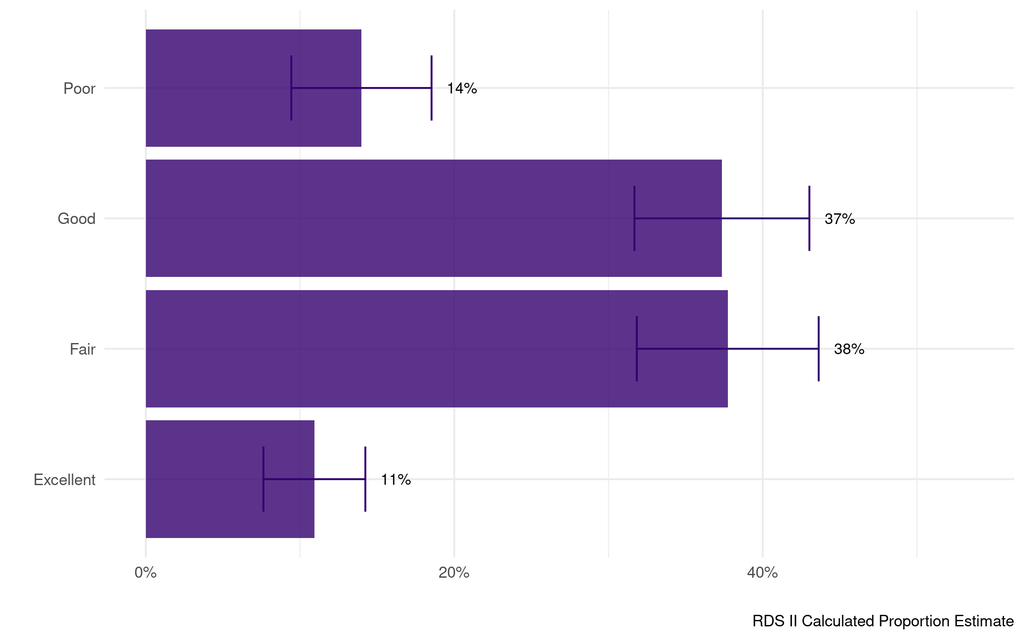

## *Disability*

*21. Do you identify as having a disability?. This variable is not included for UWRDS-PSD survey observations.*

Disability

Sample N

Sample Proportion

RDS II Estimate

RDS II 95% CI

Choose not to answer

8

0.9%

1.3%

[-0.5%, 3.1%]

Do not know

23

2.7%

3.3%

[0.9%, 5.6%]

No

379

44.4%

46.6%

[40.0%, 53.2%]

Yes

444

52.0%

48.9%

[42.4%, 55.4%]

Total

854

100.0%

100.0%

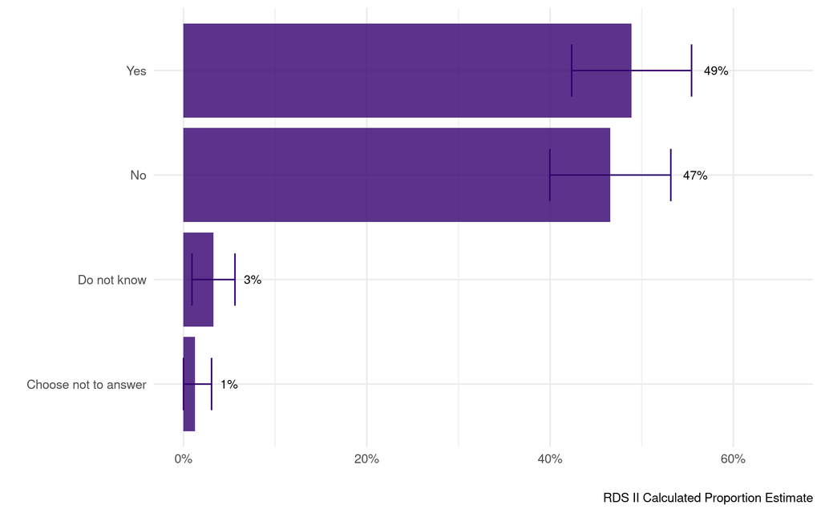

## *Mental Illness*

*20. Do you identify as having a serious mental illness?. This variable is not included for UWRDS-PSD survey observations.*

Mental Illness

Sample N

Sample Proportion

RDS II Estimate

RDS II 95% CI

Choose not to answer

12

1.4%

2.0%

[-0.04%, 4.1%]

Do not know

23

2.7%

3.1%

[0.14%, 6.1%]

No

508

59.4%

62.0%

[55.77%, 68.2%]

Yes

312

36.5%

32.8%

[26.98%, 38.7%]

Total

855

100.0%

100.0%

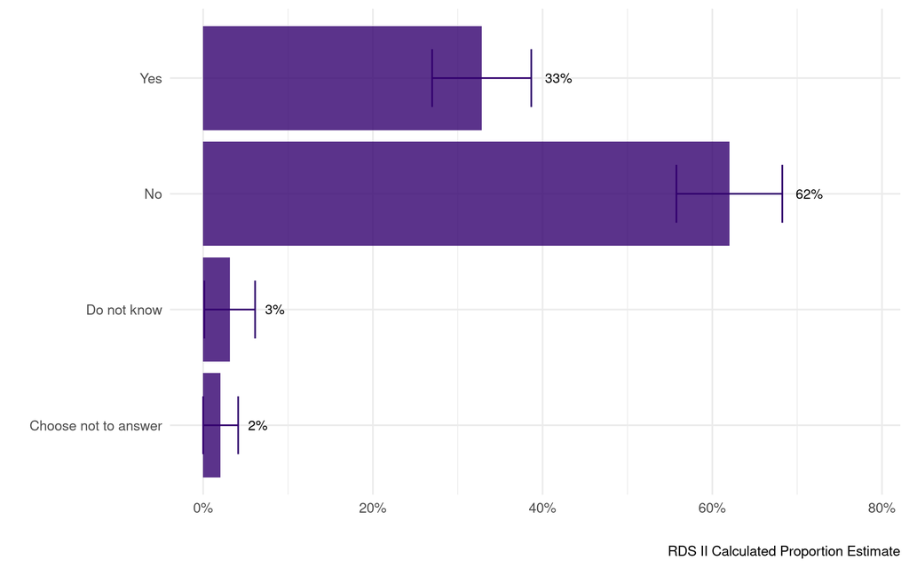

## *Substance Use*

*22. Do you identify as having a substance use disorder?. This variable is not included for UWRDS-PSD survey observations.*

Substance Use

Sample N

Sample Proportion

RDS II Estimate

RDS II 95% CI

Choose not to answer

12

1.41%

2.03%

[-0.49%, 4.55%]

Do not know

7

0.82%

1.37%

[-0.94%, 3.69%]

No

428

50.12%

53.78%

[47.26%, 60.30%]

Yes

407

47.66%

42.82%

[36.44%, 49.20%]

Total

854

100.00%

100.00%

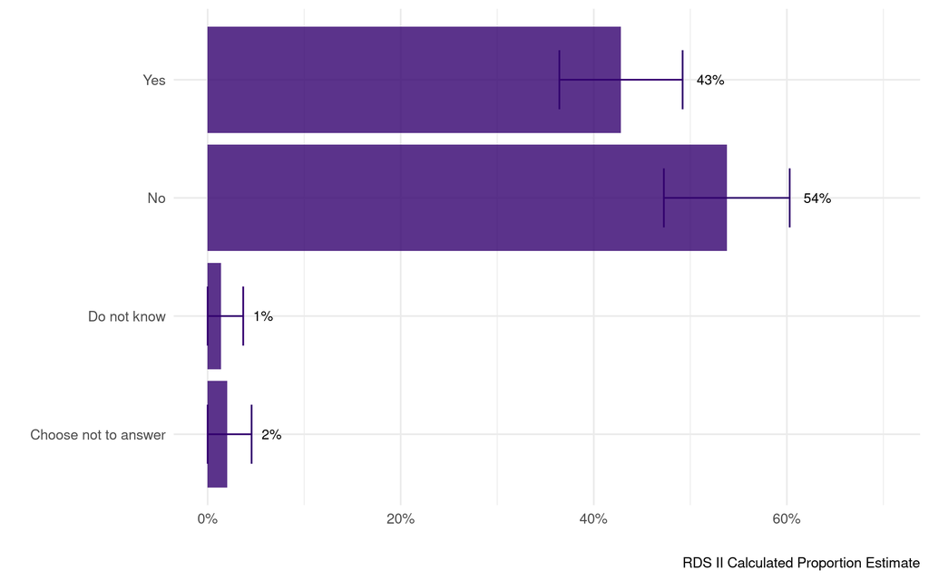

# Eviction

## *Ever Evicted*

*Based on ‘15. Have you ever been evicted from a rental property?’ [UWRDS] and ‘Now think about the last place you lived, before you moved to your current residence. Were you forcibly evicted from that last place you lived?’ [UWRDS-PSD]*

Ever Evicted

Sample N

Sample Proportion

RDS II Estimate

RDS II 95% CI

No

696

75%

76%

[70%, 81%]

Yes

234

25%

24%

[19%, 30%]

Total

930

100%

100%

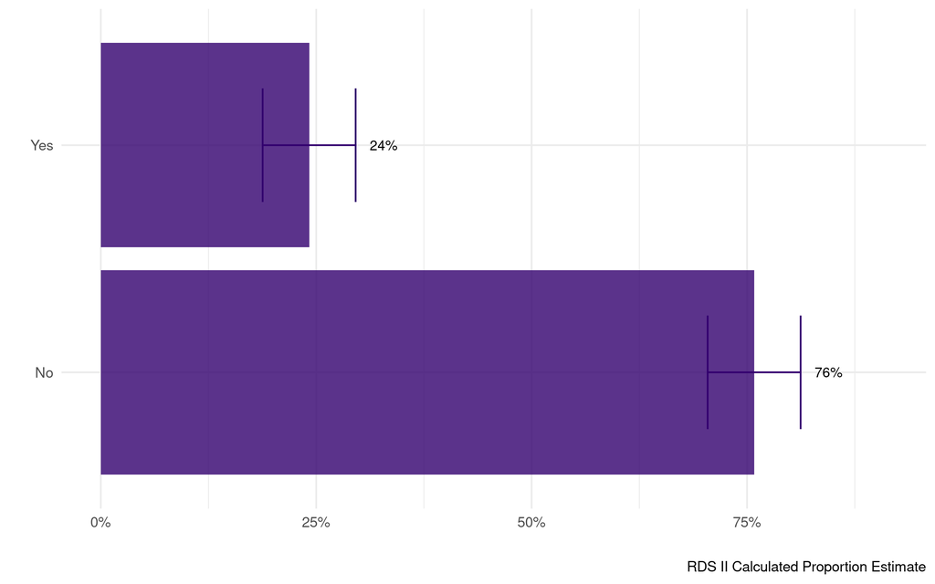

## *Age at Eviction*

*15.1 How old were you? (please enter a number, for example: 30)- Imputed. This variable is not included for UWRDS-PSD survey observations.*

| Eviction Age | Sample N | Sample Median | Sample Mean | Sample SE | RDS II Estimate | RDS II 95% CI |
| --- | --- | --- | --- | --- | --- | --- |
| • | 207 | 28 | 31.26 | 0.89 | 31.92 | [28.5, 35.35] |

## *If Evicted, Ever Formally Evicted*

*15.2 Were you formally evicted by court order?. This variable is not included for UWRDS-PSD survey observations.*

Ever Formally Evicted

Sample N

Sample Proportion

RDS II Estimate

RDS II 95% CI

No

108

52.4%

52.9%

[39.0%, 66.8%]

Yes

98

47.6%

47.1%

[33.2%, 61.0%]

Total

206

100.0%

100.0%

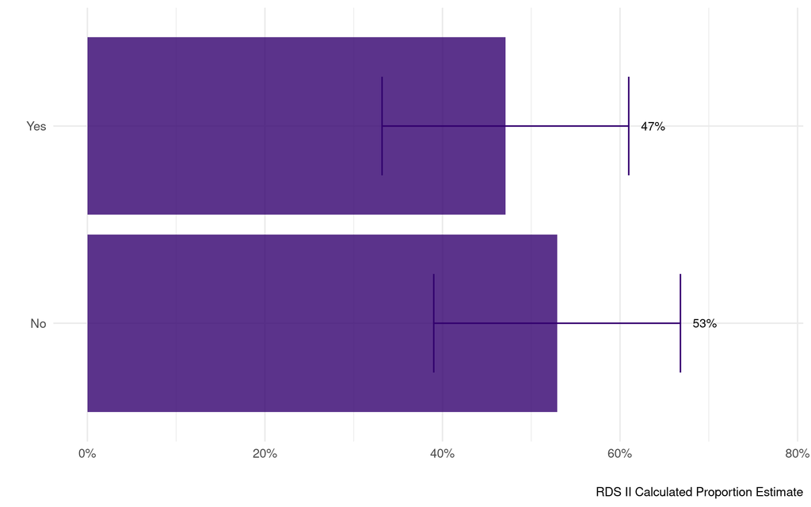

# Sleep Status

## *Location Slept Previous Night*

### *Where did you sleep last night?*

*Respondent sleep status based ‘A. Regular residence’ in UWRDS-PSD and ‘7. Where did you sleep last night?’ UWRDS*

Sleep Location

Sample N

Sample Proportion

RDS II Estimate

RDS II 95% CI

“Tiny home”

4

0.37%

0.29%

[-0.02%, 0.61%]

Apartment

8

0.74%

1.17%

[-0.31%, 2.65%]

Car or RV

159

14.71%

13.14%

[9.56%, 16.71%]

Homeless shelter or hotel

100

9.25%

10.26%

[6.13%, 14.38%]

Mobile home or trailer

2

0.19%

0.24%

[-0.12%, 0.60%]

No residence, I sleep outdoors

252

23.31%

26.10%

[20.65%, 31.54%]

Single-family house

3

0.28%

0.36%

[-0.05%, 0.78%]

Something else

298

27.57%

27.08%

[22.09%, 32.07%]

Tent or homemade structure

255

23.59%

21.36%

[17.15%, 25.57%]

Total

1081

100.00%

100.00%

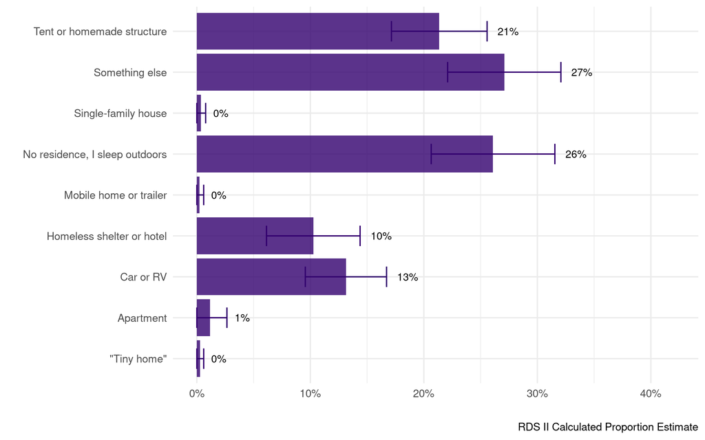

### *Re-coded: Where did you sleep last night?*

*7. Where did you sleep last night? - Imputed*

Sleep Location

Sample N

Sample Proportion

RDS II Estimate

RDS II 95% CI

Chose not to answer

2

0.23%

0.20%

[-0.21%, 0.62%]

Commercial property (e.g. shops)

1

0.12%

0.16%

[-0.34%, 0.66%]

Did not sleep

18

2.10%

1.63%

[0.76%, 2.50%]

Doubled-up: couchsurfing, staying with friend or family

113

13.20%

12.22%

[8.09%, 16.35%]

Housed, other (e.g. in apartment, house)

49

5.72%

5.53%

[3.23%, 7.83%]

In a car, truck, or van (smaller vehicle)

81

9.46%

9.09%

[5.28%, 12.90%]

In a hotel or motel

20

2.34%

2.88%

[0.24%, 5.51%]

In a park (uncovered, like on a bench)

19

2.22%

2.34%

[1.43%, 3.25%]

In a public facility or transit (bus/train station, transit center, hospital waiting room)

41

4.79%

5.73%

[2.85%, 8.61%]

In an RV, trailer, or bus (larger vehicle)

46

5.37%

4.22%

[2.47%, 5.97%]

In an abandoned building/backyard or storage structure

16

1.87%

1.77%

[0.03%, 3.52%]

In an overnight shelter (e.g. mission, church, resource shelter, etc.)

63

7.36%

8.66%

[4.13%, 13.20%]

Institutions such as jails, hospitals, or nursing facilities

2

0.23%

0.27%

[-0.06%, 0.60%]

Maritime accommodation (e.g. boats, cargo)

3

0.35%

0.46%

[0.10%, 0.82%]

Outside in a tent (or tent-like structure)

194

22.66%

20.21%

[15.53%, 24.88%]

Outside, not in a tent

166

19.39%

21.83%

[15.77%, 27.89%]

Subsidized housing, housing vouchers

4

0.47%

0.57%

[-1.01%, 2.16%]

Tiny homes (not self-constructed)

3

0.35%

0.23%

[-0.08%, 0.54%]

Transitional, supportive, or halfway housing

3

0.35%

0.39%

[-1.30%, 2.08%]

Unsure, unknown, ambiguous

11

1.29%

1.49%

[0.03%, 2.96%]

Workplace

1

0.12%

0.11%

[0.08%, 0.13%]

Total

856

100.00%

100.00%

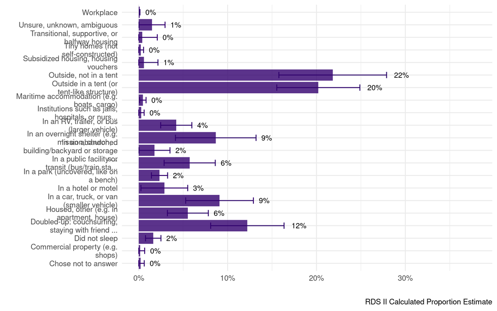

## *Sheltered vs. Unsheltered*

*Binary variable representing sheltered status based on previous sleep location for respondent*

Sheltered vs. Unsheltered

Sample N

Sample Proportion

RDS II Estimate

RDS II 95% CI

Sheltered

111

13%

14%

[9%, 20%]

Unsheltered

748

87%

86%

[80%, 91%]

Total

859

100%

100%

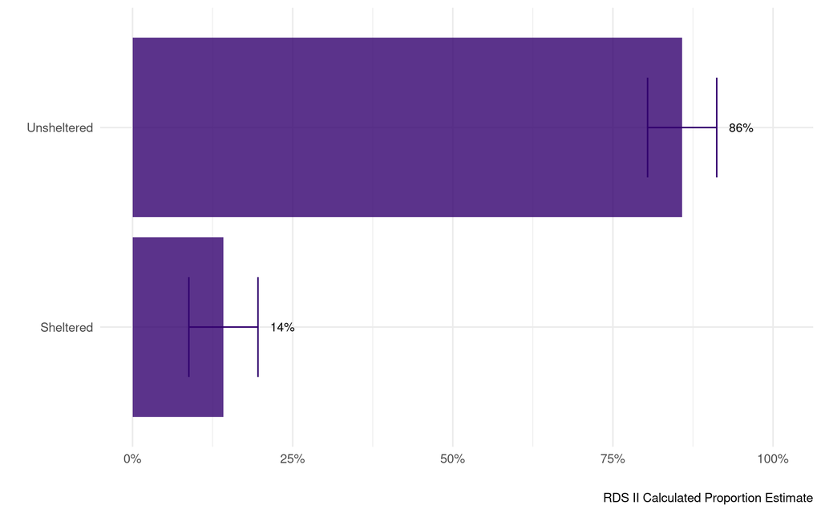

## *Would Accept Shelter*

*12. If you were offered a space in an emergency shelter this week, would you accept?. This variable is not included for UWRDS-PSD survey observations.*

Accept Shelter

Sample N

Sample Proportion

RDS II Estimate

RDS II 95% CI

No

347

41%

41%

[35%, 48%]

Prefer not to answer

34

4%

4%

[1%, 7%]

Yes

475

55%

55%

[48%, 61%]

Total

856

100%

100%

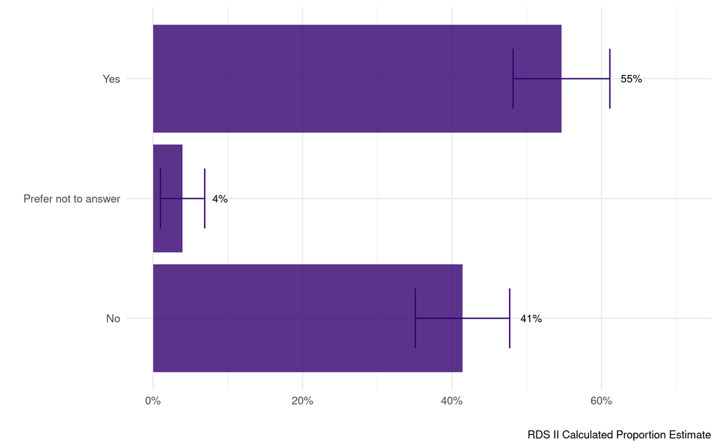

## *If Accepting, Shelter Preference

*Variable based on Which of the following would you prefer for an emergency shelter? - Imputed. This variable is not included for UWRDS-PSD survey observations.*

Shelter Preference

Sample N

Sample Proportion

RDS II Estimate

RDS II 95% CI

Prefers Hotel or Motel

83

61.0%

56.6%

[39.7%, 73.5%]

Prefers Indoor Overnight Shelter

19

14.0%

12.3%

[6.1%, 18.5%]

Prefers Safe Parking Space to Live in Vehicle

5

3.7%

4.8%

[-2.3%, 12.0%]

Prefers Tiny House Village

29

21.3%

26.3%

[9.2%, 43.4%]

Total

136

100.0%

100.0%

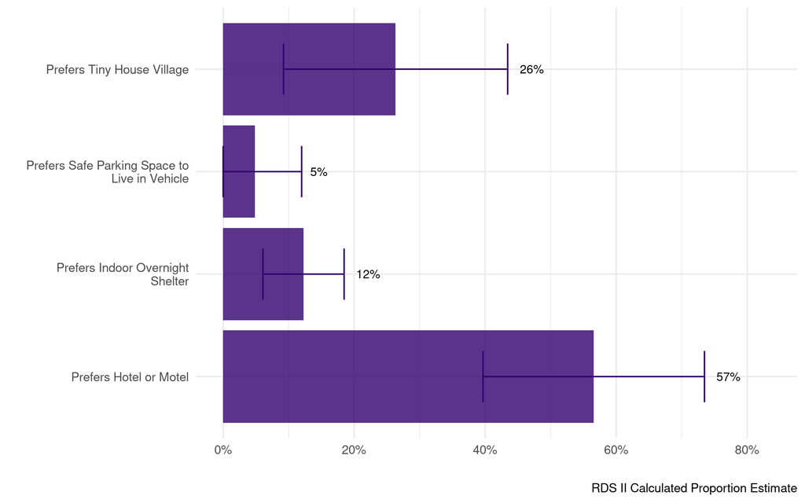

# Experience of Homelessness

## *First Year Experiencing Homelessness*

*10. What year was your first experience of homelessness?. This variable is not included for UWRDS-PSD survey observations.*

| First Homeless Year | Sample N | Sample Median | Sample Mean | Sample SE | RDS II Estimate | RDS II 95% CI |
| --- | --- | --- | --- | --- | --- | --- |
| • | 850 | 2014 | 2009.84 | 0.42 | 2009.94 | [2008.01, 2011.86] |

## *Time Experiencing Homelessness*

*Imputed based on ‘About how long have you been homeless’ [UWRDS-PSD] and 17. How long have you been homeless this time?’ [UWRDS-PSD]*

Duration Homeless

Sample N

Sample Proportion

RDS II Estimate

RDS II 95% CI

Above one year

722

72.86%

69.56%

[63.64%, 75.5%]

Choose not to answer

15

1.51%

1.72%

[-0.37%, 3.8%]

Do not know

10

1.01%

0.74%

[0.18%, 1.3%]

Less than a month

48

4.84%

6.01%

[2.69%, 9.3%]

More than a month but Less than a year

196

19.78%

21.98%

[16.66%, 27.3%]

Total

991

100.00%

100.00%

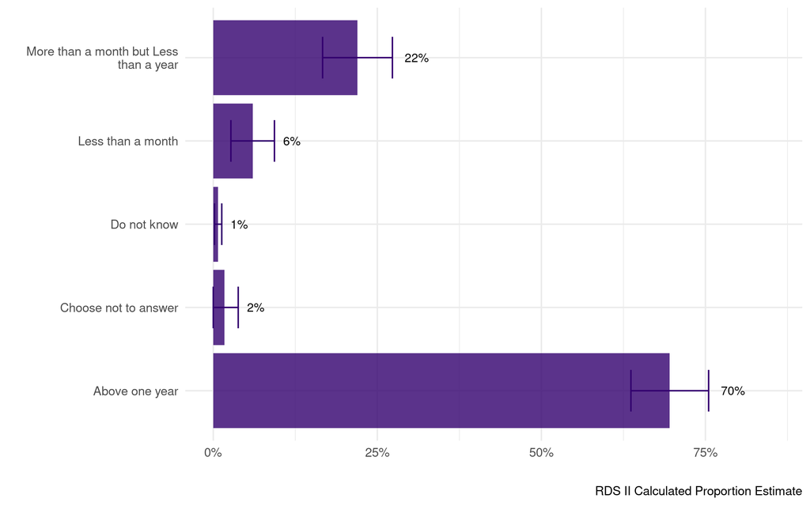

## *Days Homeless in Past Three Years*

*If you added up all the times you have been homeless in the last 3 years, about how long have you been homeless? - Imputed Total Days. This variable is not included for UWRDS-PSD survey observations.*

| Total Days Homeless | Sample N | Sample Median | Sample Mean | Sample SE | RDS II Estimate | RDS II 95% CI |
| --- | --- | --- | --- | --- | --- | --- |
| • | 860 | 1095 | 800.73 | 13.2 | 782.48 | [726.84, 838.12] |

## *Number of Times Homeless in Past Three Years*

*18. Including this time, how many different times have you been homeless in the past 3 years, that is since April 2020?. This variable is not included for UWRDS-PSD survey observations.*

# Times Homeless

Sample N

Sample Proportion

RDS II Estimate

RDS II 95% CI

1 time

569

66.55%

65.70%

[59.34%, 72.05%]

2 times

114

13.33%

14.42%

[9.00%, 19.84%]

3 times

50

5.85%

6.21%

[3.85%, 8.57%]

4 or more times

89

10.41%

9.44%

[5.80%, 13.08%]

Choose not to answer

15

1.75%

1.93%

[0.14%, 3.72%]

Do not know

18

2.11%

2.30%

[0.03%, 4.58%]

Total

855

100.00%

100.00%

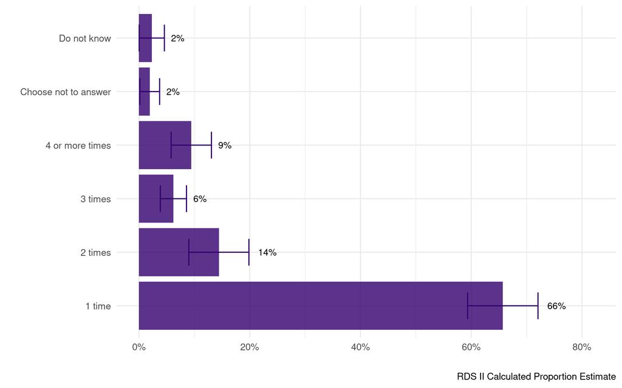

## *Experiencing Chronic Homelessness*

*Binary imputed variable for HUD’s chronic homelessness designation*

Chronic Homelessness

Sample N

Sample Proportion

RDS II Estimate

RDS II 95% CI

No

355

41%

47.1%

[40.4%, 53.7%]

Yes

505

59%

52.9%

[46.3%, 59.6%]

Total

860

100%

100.0%

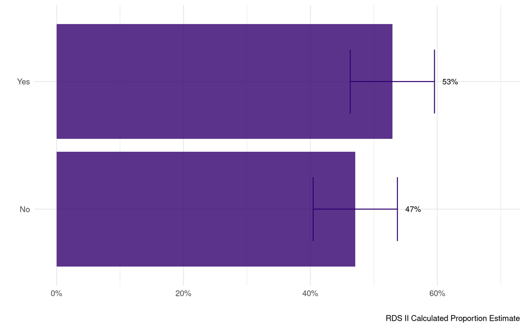

# Connections

## *Number of Estimated Homeless People Known*

*Outside of your family living with you, how many people do you personally know who are unhoused or experiencing homelessness? - Imputed*

| Estimated Connections | Sample N | Sample Median | Sample Mean | Sample SE | RDS II Estimate | RDS II 95% CI |
| --- | --- | --- | --- | --- | --- | --- |
| • | 1043 | 10 | 77.5 | 22.31 | 82.79 | [-21.81, 187.39] |

## *Number of Named Homeless People Known*

*Number of named non-household alters*

| Named Connections | Sample N | Sample Median | Sample Mean | Sample SE | RDS II Estimate | RDS II 95% CI |
| --- | --- | --- | --- | --- | --- | --- |
| • | 1085 | 3 | 4.1 | 0.13 | 1.85 | [1.6, 2.1] |

## *Number of Household Members*

*Imputed count of household alters based on ‘27. Please list the initials of all the people in your household’*

| Household Members | Sample N | Sample Median | Sample Mean | Sample SE | RDS II Estimate | RDS II 95% CI |
| --- | --- | --- | --- | --- | --- | --- |
| • | 873 | 0 | 0.67 | 0.04 | 0.59 | [0.49, 0.7] |

## *Number of Coupons Distributed*

*Total number of individuals the respondent referred who took the survey*

| Coupons Distributed | Sample N | Sample Median | Sample Mean | Sample SE | RDS II Estimate | RDS II 95% CI |
| --- | --- | --- | --- | --- | --- | --- |
| • | 1106 | 3 | 2.88 | 0.02 | 2.87 | [2.79, 2.95] |

# Benefits

## *Veteran Affairs Benefits*

*13. Are you receiving any of the following benefits? (Select all that apply) - Selected Choice Veteran’s Administration (VA). This variable is not included for UWRDS-PSD survey observations.*

VA Benefits

Sample N

Sample Proportion

RDS II Estimate

RDS II 95% CI

No or Chose Not to Answer

831

96.6%

96.8%

[95%, 98%]

Yes

29

3.4%

3.2%

[2%, 5%]

Total

860

100.0%

100.0%

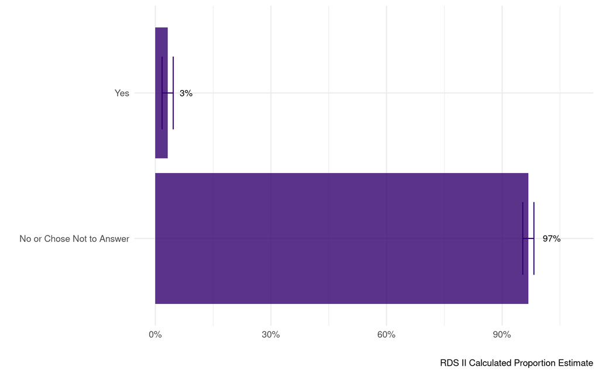

## *Disability Benefits*

*13. Are you receiving any of the following benefits? (Select all that apply) - Selected Choice WA Aged, Blind, or Disabled cash assistance. This variable is not included for UWRDS-PSD survey observations.*

Disability Benefits

Sample N

Sample Proportion

RDS II Estimate

RDS II 95% CI

No or Chose Not to Answer

785

91.3%

92.2%

[89%, 95%]

Yes

75

8.7%

7.8%

[5%, 11%]

Total

860

100.0%

100.0%

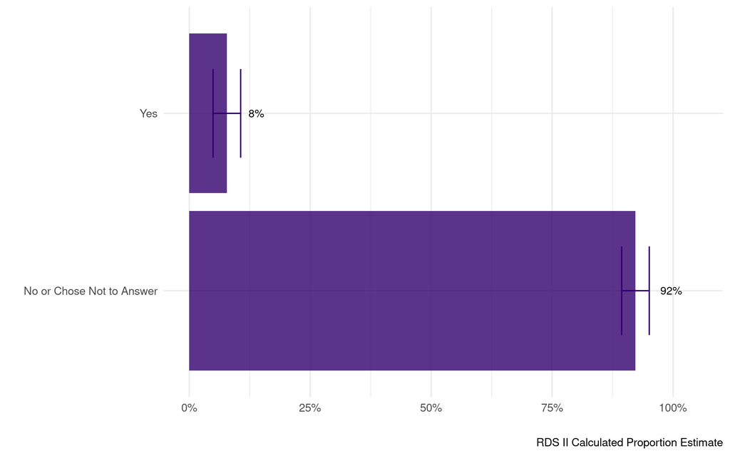

## *Housing Benefits*

*13. Are you receiving any of the following benefits? (Select all that apply) - Selected Choice WA Housing and Essential Needs program - Imputed with text response. This variable is not included for UWRDS-PSD survey observations.*

Housing Benefits

Sample N

Sample Proportion

RDS II Estimate

RDS II 95% CI

No or Chose Not to Answer

822

95.6%

97%

[96%, 98%]

Yes

38

4.4%

3%

[2%, 4%]

Total

860

100.0%

100%

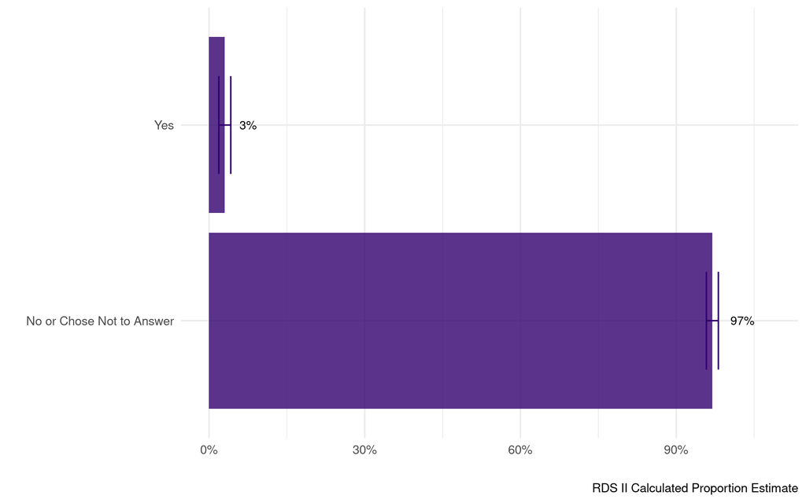

## *SSI Benefits*

*13. Are you receiving any of the following benefits? (Select all that apply) - Selected Choice Federal Supplemental Security Income (SSI), Social Security Disability Insurance (SSDI), or other social security benefit - Imputed with text response. This variable is not included for UWRDS-PSD survey observations.*

SSI Benefits

Sample N

Sample Proportion

RDS II Estimate

RDS II 95% CI

No or Chose Not to Answer

709

82%

83%

[78%, 87%]

Yes

151

18%

17%

[13%, 22%]

Total

860

100%

100%

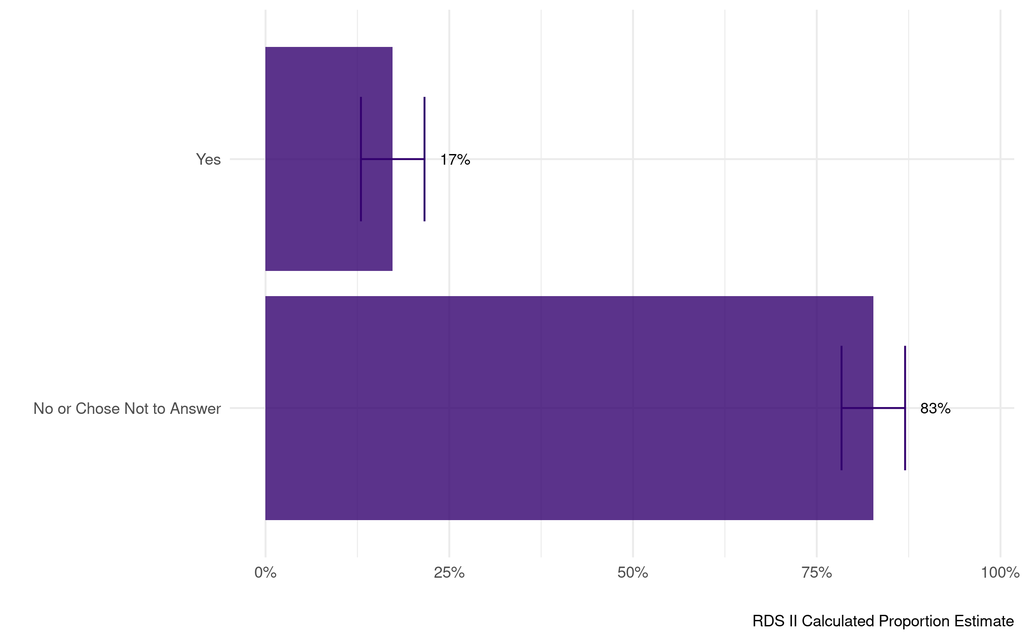

## *Medicaid Benefits*

*13. Are you receiving any of the following benefits? (Select all that apply) - Selected Choice Medicaid (in Washington state, this is Apple Health) - Imputed with text response. This variable is not included for UWRDS-PSD survey observations.*

Medicaid Benefits

Sample N

Sample Proportion

RDS II Estimate

RDS II 95% CI

No or Chose Not to Answer

401

46.6%

51.0%

[44.5%, 57.6%]

Yes

459

53.4%

49.0%

[42.4%, 55.5%]

Total

860

100.0%

100.0%

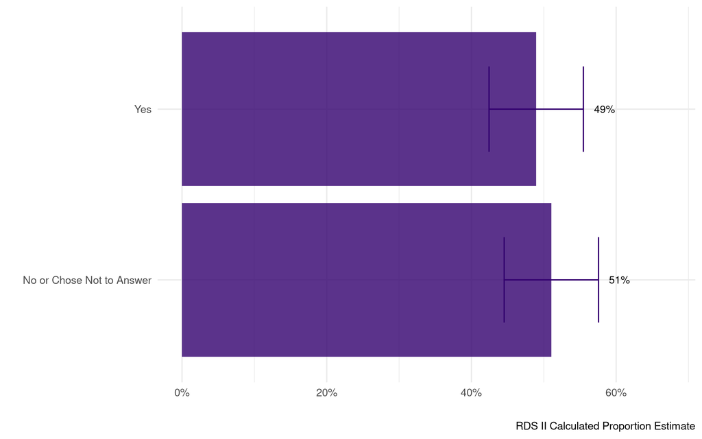

## *Medicare Benefits*

*13. Are you receiving any of the following benefits? (Select all that apply) - Selected Choice Medicare. This variable is not included for UWRDS-PSD survey observations.*

Medicare Benefits

Sample N

Sample Proportion

RDS II Estimate

RDS II 95% CI

No or Chose Not to Answer

752

87%

87%

[84%, 91%]

Yes

108

13%

13%

[9%, 16%]

Total

860

100%

100%

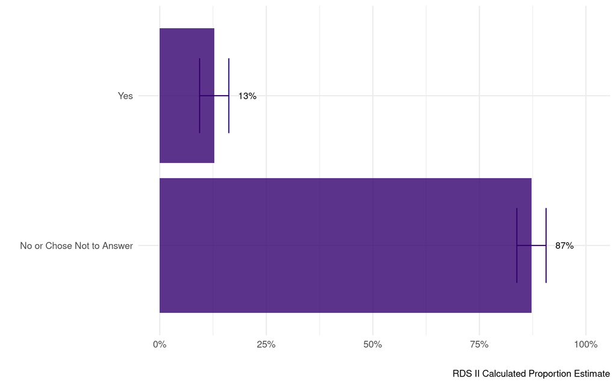

## *Indian Health Service Benefits*

*13. Are you receiving any of the following benefits? (Select all that apply) - Selected Choice Indian Health Services - Imputed with text response. This variable is not included for UWRDS-PSD survey observations.*

IHS Benefits

Sample N

Sample Proportion

RDS II Estimate

RDS II 95% CI

No or Chose Not to Answer

841

97.8%

98.4%

[97%, 100%]

Yes

19

2.2%

1.6%

[0%, 3%]

Total

860

100.0%

100.0%

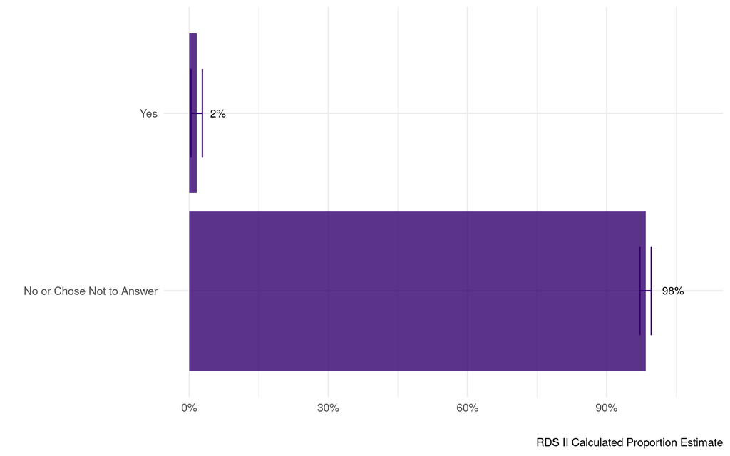

## *Other Benefits*

*13. Are you receiving any of the following benefits? - Other - Imputed. This variable is not included for UWRDS-PSD survey observations.*

Other Benefits

Sample N

Sample Proportion

RDS II Estimate

RDS II 95% CI

No or Chose Not to Answer

409

47.6%

48.5%

[42%, 55%]

Yes

451

52.4%

51.5%

[45%, 58%]

Total

860

100.0%

100.0%

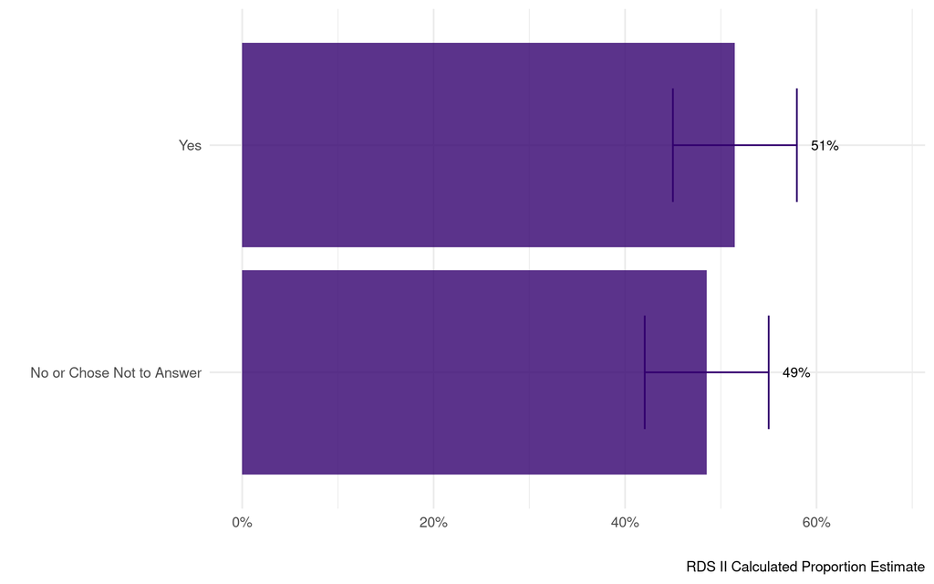